# Cereals Hierarchical Clustering

Mai Bashir

```r
library(cluster)
```

## Data Preprocessing

```r
cereals <- read.csv(file.choose())

# Remove cereals with missing values
cereals.clean <- na.omit(cereals)

# Keep only numeric variables
cereals.num <- cereals.clean[, sapply(cereals.clean, is.numeric)]

# Normalize numeric variables
cereals.norm <- scale(cereals.num)

dim(cereals)
```

```
## [1] 77 16
```

```r
dim(cereals.clean)
```

```
## [1] 74 16
```

The original dataset had 77 cereals. After removing missing values, 74 cereals remained.

## Hierarchical Clustering Using AGNES

```r
agnes.single <- agnes(cereals.norm, method = "single")
agnes.complete <- agnes(cereals.norm, method = "complete")
agnes.average <- agnes(cereals.norm, method = "average")
agnes.ward <- agnes(cereals.norm, method = "ward")

agnes.single$ac
```

```
## [1] 0.6067859
```

```r
agnes.complete$ac
```

```
## [1] 0.8353712
```

```r
agnes.average$ac
```

```
## [1] 0.7766075
```

```r
agnes.ward$ac
```

```
## [1] 0.9046042
```

Ward’s method was selected because it had the highest agglomerative coefficient, 0.9046. This means Ward’s method produced the strongest cluster structure compared with single, complete, and average linkage.

## Dendrogram

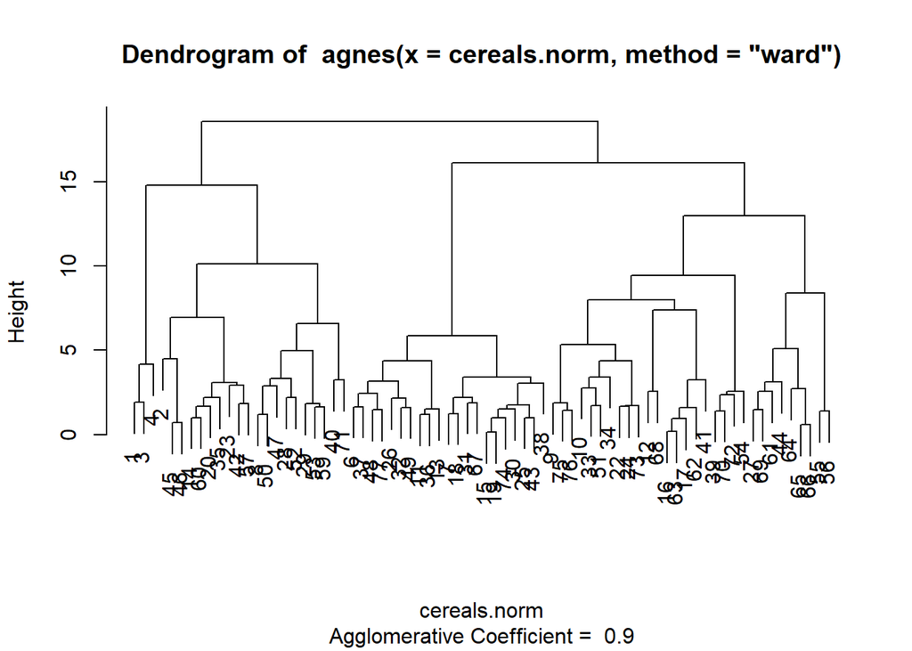

```r
plot(agnes.ward, which.plots = 2)
```

## Choosing the Number of Clusters

```r
for(k in 2:6){
  clusters.temp <- cutree(as.hclust(agnes.ward), k = k)
  sil <- silhouette(clusters.temp, dist(cereals.norm))
  cat("k =", k, "Average Silhouette =", mean(sil[,3]), "\n")
}
```

```
## k = 2 Average Silhouette = 0.2008371
## k = 3 Average Silhouette = 0.1887617
## k = 4 Average Silhouette = 0.2242571
## k = 5 Average Silhouette = 0.2580063
## k = 6 Average Silhouette = 0.261102
```

Based on the silhouette results, 6 clusters were chosen because k = 6 had the highest average silhouette value, 0.2611.

## Final Cluster Solution

```r
clusters <- cutree(as.hclust(agnes.ward), k = 6)

cereals.clean$Cluster <- clusters

table(cereals.clean$Cluster)
```

```
##
##  1  2  3  4  5  6
##  3 10 21 10 21  9
```

## Cluster Averages

```r
cluster.means <- aggregate(cereals.num,
                           by = list(Cluster = cereals.clean$Cluster),
                           mean)

cluster.means
```

```
##   Cluster  calories  protein       fat     sodium      fiber     carbo
## 1       1  63.33333 4.000000 0.6666667 176.666667 11.0000000  6.666667
## 2       2 116.00000 3.300000 2.5000000 118.000000  2.5500000 12.350000
## 3       3 110.95238 1.523810 1.0000000 172.380952  0.5714286 12.619048
## 4       4 132.00000 3.000000 1.4000000 192.000000  3.6500000 15.550000
## 5       5 103.80952 2.714286 0.5238095 226.190476  1.6666667 18.476190
## 6       6  82.22222 2.444444 0.1111111   1.666667  2.1111111 15.333333
##      sugars    potass vitamins    shelf weight      cups   rating
## 1  3.666667 310.00000 25.00000 3.000000  1.000 0.3866667 73.84446
## 2  7.800000 130.50000 22.50000 2.900000  1.000 0.6750000 40.26405
## 3 11.285714  45.95238 25.00000 1.666667  1.000 0.8871429 28.84825
## 4 10.900000 172.50000 40.00000 2.900000  1.345 0.7100000 36.25917
## 5  3.333333  73.80952 39.28571 2.095238  1.000 0.9295238 46.46513
## 6  2.333333  90.55556 11.11111 2.000000  0.870 0.8488889 63.01840
```

## Cereals in Each Cluster

```r
cereals.clean[, c("name", "Cluster")]
```

```
##                                      name Cluster
## 1                               100%_Bran       1
## 2                       100%_Natural_Bran       2
## 3                                All-Bran       1
## 4               All-Bran_with_Extra_Fiber       1
## 6                 Apple_Cinnamon_Cheerios       3
## 7                             Apple_Jacks       3
## 8                                 Basic_4       4
## 9                               Bran_Chex       5
## 10                            Bran_Flakes       5
## 11                           Cap'n'Crunch       3
## 12                               Cheerios       5
## 13                  Cinnamon_Toast_Crunch       3
## 14                               Clusters       2
## 15                            Cocoa_Puffs       3
```

[output cut: 60 more lines]

## Structure of the Clusters

The six clusters represent different nutritional profiles. Cluster 1 contains very high-fiber cereals with the highest ratings. Cluster 3 contains many sugary cereals with low fiber and lower ratings. Cluster 5 contains many traditional cereals with moderate nutritional values. Cluster 6 contains cereals with low calories, very low fat, and very low sodium.

Overall, the clusters are mainly separated by calories, sugar, sodium, fiber, protein, and rating.

## Cluster Stability

```r
set.seed(123)

# Create partition A and B
n <- nrow(cereals.norm)
partA <- sample(1:n, size = round(0.5 * n))
partB <- setdiff(1:n, partA)

dataA <- cereals.norm[partA, ]
dataB <- cereals.norm[partB, ]

# Cluster partition A using Ward
agnes.A <- agnes(dataA, method = "ward")
clusters.A <- cutree(as.hclust(agnes.A), k = 6)

# Get centroids from partition A
centroids.A <- aggregate(dataA,
                         by = list(Cluster = clusters.A),
                         mean)

centroid.matrix <- as.matrix(centroids.A[, -1])

# Assign partition B to closest centroid
assign.cluster <- function(x, centroids){
  distances <- apply(centroids, 1, function(center){
    sum((x - center)^2)
  })
  return(which.min(distances))
}

assigned.B <- apply(dataB, 1, assign.cluster, centroids = centroid.matrix)

assigned.B
```

```
##  1  2  3  4  6  7 12 14 17 19 22 23 24 26 32 35 36 39 40 42 47 48 49 50 51 54
##  1  6  1  5  3  3  1  6  4  3  4  3  1  3  3  6  3  4  2  1  2  1  3  6  1  4
## 55 56 61 62 63 64 67 69 72 76 77
##  5  5  5  4  4  5  3  5  4  1  3
```

## Healthy Cereal Cluster

Based on the cluster means, Cluster 1 is the healthiest cluster. It has the lowest calories, highest protein, highest fiber, low sugar, and the highest rating.

The healthy cereals in Cluster 1 are:

```r
cereals.clean[cereals.clean$Cluster == 1, c("name", "calories", "protein", "fiber", "sugars", "sodium", "rating")]
```

```
##                        name calories protein fiber sugars sodium   rating
## 1                 100%_Bran       70       4    10      6    130 68.40297
## 3                  All-Bran       70       4     9      5    260 59.42551
## 4 All-Bran_with_Extra_Fiber       50       4    14      0    140 93.70491
```

Cluster 1 includes 100% Bran, All-Bran, and All-Bran with Extra Fiber. These cereals would be the best choice for elementary public schools because they support a healthier diet.

## Should the Data Be Normalized?

Yes, the data should be normalized before clustering because the variables are measured on different scales. For example, sodium and potassium have much larger values than fat, fiber, or protein. Without normalization, variables with larger values would dominate the Euclidean distance calculation.

However, after clustering is complete, the original unnormalized values should be used to interpret the clusters and decide which cereals are healthiest.